# SP//dr - Web Swinging

### Peni Parker

SP//dr SYS #0 - WEBS  
Draft for web creation and swing execution. A stylized-approach to simulating physics for out-wordly gameplay.

[figure not shown]

## The Swing Motion

The motion of a web can be broken into 4 parts; the draw, stick, follow, and release.

### Draw

The draw is the creation of a web, initiated by player input and lasting until the web connects SP//dr to its high-rise targets. Web drawing is when webs are free-flying, characterizing the entire feature's style and availability.  
This comes at the cost of a delay between player input and direct physical feedback. It is mostly ommitted in Insomniac's Spiderman games which use an instantaneous web creation method. And this keeps the motion quick, clean, and reactive. Its perfect in their use case, which requires fast and easy control.  
For SP//dr, I want webs to have a lively feel everytime. The delay between shooting a web and getting pulled by it, gives the web resource-value and allows players to be more mindful of gravity whilst in free fall. If a web takes time, even half a second, to setup then it becomes less expendable and more valuable.

### Stick

The stick is a snappy motion between a loose free web and an elastic taut one immediately after the web connects to its target. It characterizes a tightening stucture, where no new webbing is produced and the existing web begins to compress to satisfy a higher tension by compressing into a linear shape.  
This stage aims to provide a clean transition between shooting a web and being able to swing with it. Visually, this should be very stylistic (although quick) as a sequel to the draw. Physically, this needs to hype up the swing by pulling the character towards the target.  
This is where a physical constraint it made which makes the swinging physics possible; however it is transitioned in from the draw. It is also a procedural stage, where if the distance of the web approaches its max length, the visuals agree.

### Follow

Coming soon

### Release

Coming soon

# Source Code

### System Dependencies and Globals

A config panel for SP//dr hardware (living in our software)

```python
import numpy as np
import math
import matplotlib.pyplot as plt
from matplotlib.animation import FuncAnimation
from mpl_toolkits.mplot3d import Axes3D
from IPython.display import HTML
%matplotlib inline
```

```python
# CONFIG
WEB_GRAVITY=-60 # Gravity acceleration
THWIP_0 = 960 # Firing velocity of webs

MAX_WIND = 120


# CODES
ERROR = -1
NOT_POSSIBLE = -2
```

```python
class vector2:
    def __init__(self, x=0, y=0):
        self.x = x
        self.y = y
        self.magnitude = math.sqrt((self.x**2)+(self.y**2))
        self.yx_theta = math.pi/2 if (self.x==0) else math.atan(self.y/self.x)
    def __add__(self, comp):
        return vector2(self.x+comp.x, self.y+comp.y)
    def __sub__(self, comp):
        return vector2(self.x-comp.x, self.y-comp.y)
    def __mul__(self, scalar):
        return vector2(self.x*scalar, self.y*scalar)


class waypoint:
    def __init__(self, pos=vector2(), vel=vector2()):
        self.pos = pos
        self.vel = vel

    def __add__(self, comp):
        assert(isinstance(comp, waypoint))
        self.pos = self.pos + comp.pos
        self.vel = self.vel + comp.vel
```

## The Draw

The style and setup of a swing. Given character position and attach point **draw** a trajectory path for the webbing to follow. Allow gravity to influence this path, but ignore air resistance. Firing-velocity and gravity variables are configurable. Foundation of the web shape.

### Constraints

- Fire at start point; connect at target point
- Minimize firing angle (theta) and time of travel
- Take in (starting point, target point)  
  Return point positions
  - Given any time t return appropriate point on path, clamped on interval [0, total_time].
  - Efficient $\Theta$(1); called every physics frame per web point. Resulting in $\Theta$(n) complexity for updating n points in a single physics frame.

```
[]
```

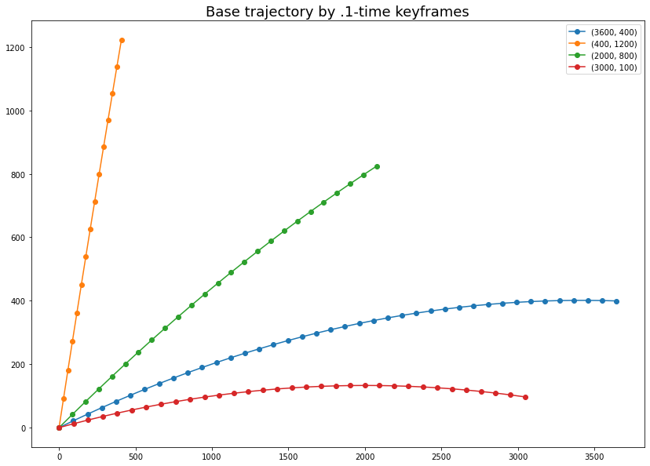

```python
def drawArc(orig, targ, t_int=1):
    off = targ-orig

    try: # Quadratic formula to get theta
        G = (.5*WEB_GRAVITY)*((off.x**2)/(THWIP_0**2))
        quad = math.sqrt(off.x**2-(4*G*(G-off.y)))
        z1 = (-off.x + quad)/(2*G)
        z2 = (-off.x - quad)/(2*G)
        theta = min(math.atan(z1), math.atan(z2))

    except:
        return NOT_POSSIBLE

    points=[]
    THWIP_X = THWIP_0*math.cos(theta)
    THWIP_Y = THWIP_0*math.sin(theta)
    total_time = off.x / THWIP_X
    for i in range(0, 1+math.ceil(total_time/t_int)):
        ti = t_int*i
        vel = vector2(THWIP_X, THWIP_Y + (WEB_GRAVITY*ti))
        pos = vector2(THWIP_X*ti, (THWIP_Y*ti)+(WEB_GRAVITY*.5*(ti**2)))
        points+=[waypoint(pos, vel)]

    return points

targets = [vector2(3600,400), vector2(400,1200), vector2(2000,800), vector2(3000,100)]
fig, ax = plt.subplots(figsize=(14,10))
for targ in targets:
    path = drawArc(vector2(0,0), targ, .1)
    x_vals, y_vals = [pt.pos.x for pt in path], [pt.pos.y for pt in path]
    ax.plot(x_vals, y_vals, 'o-', label="({}, {})".format(targ.x, targ.y))


plt.legend(loc="upper right")
plt.title("Base trajectory by .1-time keyframes", {'fontsize': 18})
plt.plot()
```

### Web Path - Style by randomized wind

Webbing is extremely light and should be guided by wind perpendicular to its velocity (no resistance).  
Generate wind on fly for webs, through some randomized seeding. Start by a series of random numbers and applying a smoothing function.

- `Idea`: Utilize integration, then adjust the values up/down and scale them to meet use case. Integration adds terms, so more terms added should smooth out line. Since structure is discrete, use trapezoid partitioned riemann sums.

```
[]
```

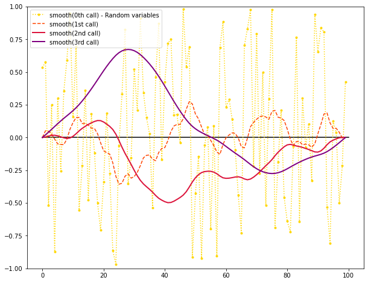

```python
def smoothIntegral(arr):
    x = arr[0]
    gral_arr = [0]
    for i in range(1, len(arr)):
        gral_arr += [gral_arr[-1] + ((arr[i]+arr[i-1])*.5)]
    return gral_arr

def rotateDown(arr): # (or up); Last value should be 0
    to = arr[-1]
    by = to/(len(arr)-1)
    for i in range(0, len(arr)):
        arr[i]-=(by*i)
    return arr

def normalize(arr, lbr=0):
    m = np.max(np.abs(arr))
    scale = np.random.random()
    scale = (scale*(1-lbr))+lbr
    m = m/scale
    return [i/m for i in arr]

def smooth(arr, rep=1, lbr=.25):
    smoothed=normalize(rotateDown(smoothIntegral(arr)),lbr)
    if rep<=1:
        return smoothed
    else:
        return smooth(smoothed, rep-1, lbr)

n=100
fig, ax = plt.subplots(figsize=(10,8))
ax.set_ylim(-1,1)
ax.plot([0,n],[0,0], color="black")

x = np.random.random(n)*2 -1
ax.plot(x, '.:', color="gold", label="smooth(0th call) - Random variables")

x=smooth(x)
ax.plot(x, '--', color="orangered", label="smooth(1st call)")

x=smooth(x)
ax.plot(x, color="crimson", linewidth='2', label="smooth(2nd call)")

x=smooth(x)
ax.plot(x, color="purple", linewidth='2', label="smooth(3rd call)")

plt.legend(loc="upper left")
plt.plot()
```

### Overlay wind

3 calls is the golden number for smooth function. Generates unique curve, without being too bumpy.  
Wind will act as the main structure to web shape on top of trajectory.  
When combining wind with trajectory path, let wind be at its greatest when perpendicular to the traveling direction. (Naive approach; new method designed later on)

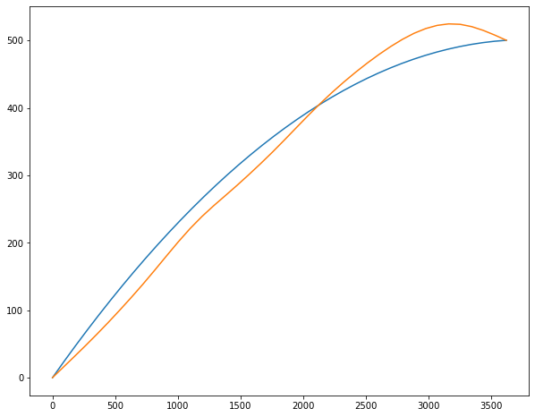

```python
def overlayWind(path):
    n = len(path)
    x_wind_acc = np.random.random(n)*2 -1
    x_wind_pos = smooth(x_wind_acc, 3)

    y_wind_acc = np.random.random(n)*2 -1
    y_wind_pos = smooth(x_wind_acc, 3)

    x_path_vel, y_path_vel = [pt.vel.x for pt in path], [pt.vel.y for pt in path]
    new_points=[]
    for i in range(0,n):
        theta=path[i].vel.yx_theta

        x_wind_pos_cor = math.sin(theta) * x_wind_pos[i] * MAX_WIND
        y_wind_pos_cor = math.cos(theta) * y_wind_pos[i] * MAX_WIND
        new_pos = path[i].pos + vector2(x_wind_pos_cor, y_wind_pos_cor)
        new_points += [waypoint(new_pos, vector2(x_path_vel[i], y_path_vel[i]))]

    return new_points

path = drawArc(vector2(), vector2(3600,500), .1)
pathWithWind = overlayWind(path)

fig, ax = plt.subplots(figsize=(10,8))
ax.plot([pt.pos.x for pt in path], [pt.pos.y for pt in path], label="Generated arc")
ax.plot([pt.pos.x for pt in pathWithWind], [pt.pos.y for pt in pathWithWind], label="With wind")
```

### 3D Path

Got that method down!  
Redefine classes and functions for a 3D model.

```python
class vector2:
    def __init__(self, x=0, y=0):
        self.x = x
        self.y = y
        self.magnitude = math.sqrt((self.x**2)+(self.y**2))

    def __add__(self, comp):
        return vector2(self.x+comp.x, self.y+comp.y)
    def __sub__(self, comp):
        return vector2(self.x-comp.x, self.y-comp.y)
    def __mul__(self, scalar):
        return vector2(self.x*scalar, self.y*scalar)
    def __truediv__(self, scalar):
        return vector2(self.x/scalar, self.y/scalar)

    def unit(self):
        if self.magnitude==0:
            return vector2()
        return vector2(self.x, self.y) / self.magnitude

    __rmul__ = __mul__

class vector3:
    def __init__(self, x=0, y=0, z=0):
        self.x = x
        self.y = y
        self.z = z
        self.magnitude = math.sqrt((self.x**2)+(self.y**2)+(self.z**2))

    # Arithmetic
    def __add__(self, comp):
        return vector3(self.x+comp.x, self.y+comp.y, self.z+comp.z)
    def __sub__(self, comp):
        return vector3(self.x-comp.x, self.y-comp.y, self.z-comp.z)
    def __mul__(self, comp):
        if type(comp)==vector3:
            return vector3(self.x*comp.x, self.y*comp.y, self.z*comp.z)
        return vector3(self.x*comp, self.y*comp, self.z*comp)
    def __truediv__(self, comp):
        if type(comp)==vector3:
            return vector3(self.x/comp.x, self.y/comp.y, self.z/comp.z)
        return vector3(self.x/comp, self.y/comp, self.z/comp)

    __rmul__ = __mul__

    def cross(self, comp):
        a,b = self, comp
        return vector3( (a.y*b.z) - (a.z*b.y),
                        (a.z*b.x) - (a.x*b.z),
                        (a.x*b.y) - (a.y*b.x))
    def unit(self):
        return vector3(self.x, self.y, self.z) / self.magnitude

class waypoint:
    def __init__(self, pos=vector3(), vel=vector3()):
        self.pos = pos
        self.vel = vel

    def __add__(self, comp):
        assert(isinstance(comp, waypoint))
        self.pos = self.pos + comp.pos
        self.vel = self.vel + comp.vel
```

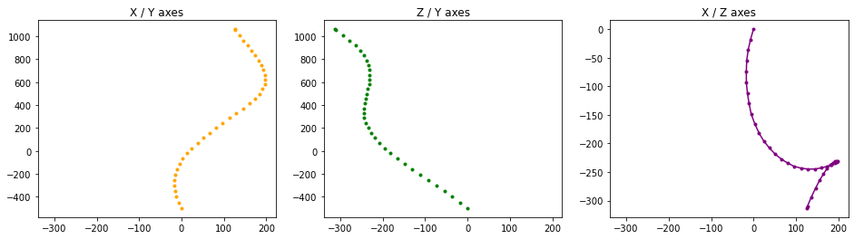

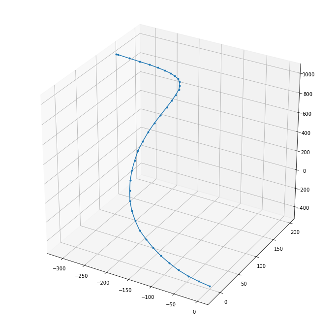

```python
def drawArc3(orig, targ, t_int=1):
    off = targ-orig
    off = vector3(off.x or 1e-5, off.y or 1e-5, off.z or 1e-5) # To avoid divide-by-zero errors

    xz = vector2(off.x, off.z).magnitude
    xz_ang = math.atan(off.z / (off.x or 1e-5))

    try: # Quadratic formula to get theta
        G = (.5*WEB_GRAVITY)*((xz**2)/(THWIP_0**2))
        quad = math.sqrt(xz**2-(4*G*(G-off.y)))
        z1 = (-xz + quad)/(2*G)
        z2 = (-xz - quad)/(2*G)
        theta = min(math.atan(z1), math.atan(z2))

    except:
        return []

    points=[]

    THWIP_Y = THWIP_0*math.sin(theta)
    THWIP_XZ = THWIP_0*math.cos(theta)
    THWIP_X = abs(THWIP_XZ*math.cos(xz_ang)) * (1 if off.x>0 else -1)
    THWIP_Z = abs(THWIP_XZ*math.sin(xz_ang)) * (1 if off.z>0 else -1)

    total_time = xz / THWIP_XZ
    for i in range(0, 1+math.ceil(total_time/t_int)):
        ti = t_int*i
        vel = vector3(THWIP_X, THWIP_Y + (WEB_GRAVITY*ti), THWIP_Z)
        pos = vector3(THWIP_X*ti, (THWIP_Y*ti)+(WEB_GRAVITY*.5*(ti**2)), THWIP_Z*ti)+orig
        points+=[waypoint(pos, vel)]

    return points


def overlayWind3(points):
    n = len(points)
    (x_wind, y_wind, z_wind) = (smooth(np.random.random(n)*2 -1, 3),
                                smooth(np.random.random(n)*2 -1, 3),
                                smooth(np.random.random(n)*2 -1, 3))
    for i in range(0,n):
        wp = points[i]
        x_ratio = (vector2(wp.vel.y, wp.vel.z).magnitude / wp.vel.magnitude)
        y_ratio = (vector2(wp.vel.x, wp.vel.z).magnitude / wp.vel.magnitude)
        z_ratio = (vector2(wp.vel.x, wp.vel.y).magnitude / wp.vel.magnitude)
        x_wind[i]*=x_ratio*MAX_WIND
        y_wind[i]*=y_ratio*MAX_WIND
        z_wind[i]*=z_ratio*MAX_WIND

        points[i].pos = points[i].pos + vector3(x_wind[i], y_wind[i], z_wind[i])


def draw(orig, targ, t_int=.1):
    assert(type(orig)==type(targ)==vector3)

    points = drawArc3(orig, targ, t_int)
    overlayWind3(points)

    total_time = t_int * len(points)

    def getPointAt(t):
        if int(t//t_int)+1>=len(points):
            return points[-1]

        p1, p2 = points[int(t//t_int)], points[int(t//t_int)+1]
        alpha = (t%t_int) / t_int # lin. interpolation

        pos = ((1-alpha) * p1.pos) + (alpha * p2.pos)
        vel = ((1-alpha) * p1.vel) + (alpha * p2.vel)
        return waypoint(pos, vel)

    return getPointAt, total_time


orig=vector3(0,-500,0)
targ=vector3(120,1000,-300)

getPointFunc, time = draw(orig, targ, .08)

(x_vals, y_vals, z_vals) = ([getPointFunc(t).pos.x for t in np.arange(0, time, .05)],
                            [getPointFunc(t).pos.y for t in np.arange(0, time, .05)],
                            [getPointFunc(t).pos.z for t in np.arange(0, time, .05)])

# 2D plot comparing each axis
fig, ax = plt.subplots(1,3,figsize=(16,4), sharex=True)
ax[0].plot(x_vals,y_vals, '.', color="orange")
ax[0].set_title('X / Y axes')

ax[1].plot(z_vals,y_vals, '.', color="green")
ax[1].set_title('Z / Y axes')

ax[2].plot(x_vals,z_vals, '.-', color="purple")
ax[2].set_title('X / Z axes')
plt.show()

# 3D plot
fig3d = plt.figure(figsize=(12,12))
ax3d = fig3d.add_subplot(projection='3d')
ax3d.plot(z_vals,y_vals,x_vals,'.-', zdir='y')
plt.show()
```

**Achieved** Amazing *into-the-spider-verse-miles-morales-leap-of-faith-type-looking-path*.

### Collisions on new path

So that web does not overlap with buildings, can use raycasting and lower-bound the wind offset where collisions might occur. This check is made from original position to wind offset. Only check for buildings so that a street light doesn't cause weird behavior. If there is a building or connect point in the direct line of path, connect there instead.

### Dynamic Web Shape

The beast of the draw and what makes this a stylized approach to custom physics. We can efficiently shape a web in 3D space with an array of points. However, a static path all points follow on isn't very aesthetic. Want points to look like a shooting string.  
Time to reverse-engineer spiderman web animations and drawings. (Literally how this entire method was made; reverse-engineering drawings)

**Characteristics of shooting web**

- `Pulls in on itself`; Web will always try and balance itself so that when pulled, points approach the center of string. Simulated with some cooking twine, but very secretive for how to define a force at each point on a variable frame rate. Discovered, an average of all points in front of update operation is a perfect approach to a pulling force.
- `Web is growing and traveling at high speed`; This contrasts the above quality, suggesting less string tension and that the direction points travel are in the direction they are already traveling (often away from center).

**The beautiful sum**  
Adding both qualities produces a web which looks together, but loose and free-form. This approach would not work in a true-physics based system. The web points here are not connected, but the direction they move acts as if they are (Length between points is not fixed). And I'm very happy with this technique, it turns animation into the reality for our web shaping rules.

**Finding difference globally**  
Getting this right took a few iterations. But I noticed when simulating the characteristics above, frame rate would often be a problem in local-based approaches (point would only move towards point in front of it).  
Instead characterstics should work globally as if the web was continuous and moving in real time.

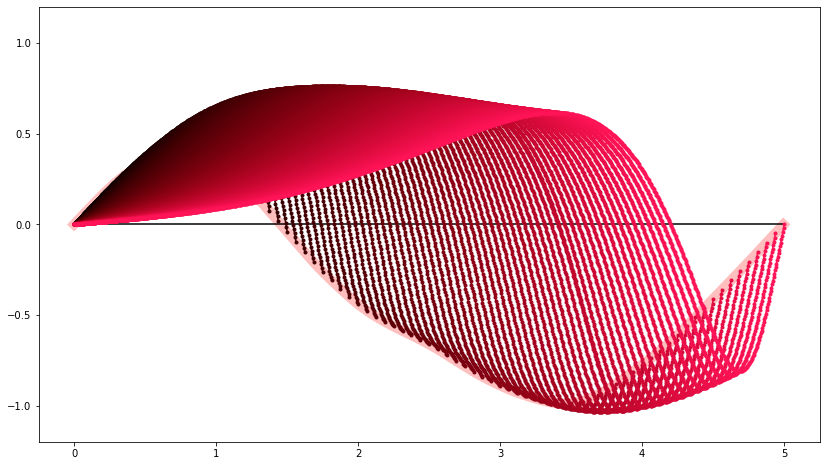

```python
class wpoint: # Wind point
    def __init__(self, y=0, alive=0):
        self.y = y
        self.alive = alive


def thwipDraw(total_time, frame_rate, n, plot_interval):
    # Wind
    wind_points = smooth(np.random.random(n)*2 -1, 3, .6)
    def windLookup(t):
        t_int = total_time / n
        l_idx, u_idx = min(n-1, max(0, int(t//t_int))), min(n-1, max(0, int(t//t_int)+1))

        alpha = (t%t_int)/t_int
        return (wind_points[l_idx]*(1-alpha)) + (wind_points[u_idx]*alpha)

    # Plot
    fig, ax = plt.subplots(figsize=(14,8))
    ax.set_ylim(-1.2,1.2)
    ax.plot([0, total_time], [0,0], color="black") # x-axis

    true_line = [windLookup(t) for t in np.arange(0, total_time, frame_rate)]
    ax.plot(np.arange(0, total_time, frame_rate) , true_line, '-', linewidth=10, color='red', alpha=.25, zorder=0)

    plot=[[], []]


    t_int = total_time / n
    points=[wpoint(windLookup(0))]

    for fr in np.concatenate((np.arange(frame_rate, total_time, frame_rate), [total_time])):
        # Update points
        head = points[-1]
        pullSum = .5 * (head.y+windLookup(fr))
        head.alive += frame_rate
        head.y = windLookup(head.alive)

        for i in range(2, len(points)+1):
            p = points[-i]
            pull = (frame_rate *
                    ((pullSum/(i-1)) - p.y) /
                    ((t_int*i + frame_rate)/2)
                   )

            out = frame_rate * p.y/p.alive # Outward force in direction of velocity

            vel = (pull*.25) + (.75*out) # Blend
            pullSum += p.y + (.5 * vel)
            p.y+= vel
            p.alive += frame_rate


        # Add new points
        tail = points[0]
        for t_new in np.arange(tail.alive, 1e-5, -t_int)[1:]:
            y = (tail.y * (t_new/tail.alive)) #windLookup(t_new)
            p = wpoint(y, t_new)
            points = [p] + points

        if (fr-frame_rate)//plot_interval<fr//plot_interval:
            a = fr/total_time
            x_vals, y_vals = [i.alive for i in points], [i.y for i in points]
            ax.plot(x_vals,y_vals,'.-', color=( a**1.25, (.6*a)**5, (.7*a)**3 ))

            plot[0]+=[x_vals]
            plot[1]+=[y_vals]

    return plot[0], plot[1]


wd1_xData, wd1_yData = thwipDraw(5, 1/160, 1000, 1/16)
```

```python
# Animation of wind over time
fig, ax = plt.subplots(figsize=(14,8))

line, = ax.plot([],[],'-', linewidth=2, color="red")
ax.set_ylim(-1.2,1.2)
ax.set_xlim(0,5)
ax.plot([0, 5],[0,0], color="black")

def animate(i):
    line.set_data([0]+wd1_xData[i], [0]+wd1_yData[i])

anim = FuncAnimation(fig, animate, interval=40, frames=len(wd1_xData))

plt.close()
HTML(anim.to_jshtml())
```

[figure not shown]

### Components of web shape

Web shape is made up of several components which influence the position of each point.

- `Foundation`: Arc generated with gravity, directly to target. Guides point along x,y,z axes over time.
- `Structure`: Dynamic wind offset defined above. Gives web its unique style.
- `Ground`: A direct line from character to target.
- `Filters`: A series of filters which combine Foundation and Structure with Ground. This extends some characteristics we want for the web.

### Web synthesis

This technique is influenced partly by sound design methods which utilize filters to shape sound waves. Apply filters to help characterize web over an `envelope`. (Dervived from sound envelope)

- `Attack`: Curve, starting low, upwards where web *catches* wind stream.
- `Delay`: Create another curve down from attack to normal level of structure. Overall should look like a bubble.
- `Sustain`: Sustain at full level until web sticks.
- `Release`: When web connects, sweep an oscillating filter from target to character to flatten web into its linear shape. (Most of the stick process)

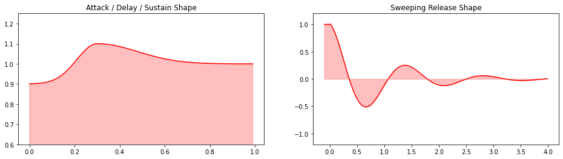

```python
def gaussPass(center=0, sigma=1, scale=1): # Sweeping gaussian curve
    def retEq(x, center=center):
        return (np.e**(-.5*(((x-center)/sigma)**2))) *scale
    return retEq

ATTACK = .3 # Length of time for attack shaping
DELAY = .6 # Length of time for delay shaping


P0, P1, P2 = .9, 1.1, 1 # Amp start, peak, and sustain level respectively

def attackFilter():
    base = gaussPass(scale = P1-P0, sigma= ATTACK * .3, center = ATTACK)
    def retEq(x):
        return base(x)+P0
    return retEq

def delayFilter():
    base = gaussPass(scale = P1-P2, sigma=DELAY * .3, center = ATTACK)
    def retEq(x):
        return base(x)+P2
    return retEq

def webCatch():
    attackFunc = attackFilter()
    delayFunc = delayFilter()

    def retEq(x):
        if x<0:
            return P0
        elif x>ATTACK+DELAY:
            return P2
        elif x<ATTACK:
            return attackFunc(x)
        else:
            return delayFunc(x)
    return retEq


amp = 1
freq= -4.4
peak = 1.02

def sweepBounce():
    offset = 0 #.12
    def retEq(x):
        if x<0:
            return P2
        x -= offset
        return peak*(np.e**(-x/amp) * math.cos(x*freq))
    return retEq


catchFunc = webCatch()
x1_vals = np.arange(0,1,.01)
y1_vals = [catchFunc(x) for x in x1_vals]

sweepFunc = sweepBounce()
x2_vals = np.arange(-.1,4,.01)
y2_vals = [sweepFunc(x) for x in x2_vals]

fig, ax = plt.subplots(1, 2, figsize=(16,4))
ax[0].plot(x1_vals, y1_vals, color='red')
ax[0].set_ylim(.6,1.25)
ax[0].fill_between(x1_vals, 0, y1_vals, color='red', alpha=.25)
ax[0].set_title("Attack / Delay / Sustain Shape")

ax[1].plot(x2_vals, y2_vals, color='red')
ax[1].fill_between(x2_vals, 0, y2_vals, color='red', alpha=.25)
ax[1].set_title("Sweeping Release Shape")
ax[1].set_ylim(-1.2,1.2)
plt.show()
```

# The Stick

Webbing sticks to the target locking the current shape of web to a strong and tight form.

**Behavior Constraints**

- Constrain max distance between SP//dr and target. Acts as primary force to swinging physics. Instantiate this constraint on a length based off wind and arc (actual length).
- Spread nodes over linear path between SP//dr and target.
- Compress web nodes by a constant factor. Webbing will tighten slightly (longer webs have more pull; more reward). Built from existing full length, compresses to factor of that.
- Quick motion. Web shape needs to change quickly and showcase multiple characterstics in a short lifetime. Overally needs to look clean and cohesive through multiple filters and offsets.
- Visually finite web. If player is distancing from target during this stage, then the web should approach line in same sense.

**How we're going to do it**

- Define new method of changing wind offset between time frame.
- Define a method to compress web points along a single vector and linear shape. Create a filter to highlight when web points begin compression.
- Create an interpolation shape to combine the two methods above. (Sweeping release filter shown above.)

### Webwork

Webbing gains a defined structure and constrained behaviour.

### Web shooting

Okay, this'll be amazing.  
SP//dr will be constantly moving, so origin of path will also need to be dynamic. Each frame, can redraw path to constant target position. For smooth transition between paths, lin. interpolate between both based on time new point created.

**Each point needs to track**

- Arc Position (Vector3)
- Arc Velocity (Vector3); For moving arc position between frames
- Wind Pos (Vector2); For dynamic change on wind
- Linear Pos (Vector3);
- Relative time (Scalar); Time until point will hit target (can be negative), For creating new points

**Additional point properties**

- Wind Plane (Vector3, Vector3); Unit vectors to apply 2D wind onto for 3D offset. Both vectors are orthogonal to travel velocity
- Filter Overload Value (Scalar); How much wind+arc is interpolated with direct line to target.
- Render Position (Vector3); Position to render point at

**Web properties**

**Quick redfinition of 3D velocity** `New Idea`: Generate 2 random wind streams for a plane parallel to the travelling velocity; both axes perpendicular to travel velocity. Results in a cleaner look since wind change will always be acting in the same direction as travel velocity.